# Protected Areas and Rural Livelihoods: Long-Run Evidence from Madagascar

Draft Manuscript

Authors

Affiliation

[Author 1]

[Affiliation]

[Author 2]

[Affiliation]

Published

March 11, 2026

# Abstract

We estimate the causal effect of the Ankarafantsika National Park establishment (2002–2003) on household income in surrounding rural communities in Madagascar. Combining a unique 20-year household panel (1999–2014) from the Réseau des Observatoires Ruraux with a new 2025 resurvey, we employ two complementary identification strategies. First, a generalized synthetic control method (gsynth) exploiting 74 donor sites from 10 rural observatories identifies a medium-run average treatment effect on the treated of approximately −0.43 log points on total household income over 2003–2014, robust across a leave-one-out sensitivity analysis (SD = 0.023 across 74 exclusions). Second, a long-run repeated cross-section difference-in-differences comparing 1999–2002 baselines to 2025 outcomes estimates a decline of 0.43–0.75 log points, depending on the control group. Both estimates are imprecise given the small number of treated clusters (2 sites), and permutation inference and wild cluster bootstrap yield p-values of 0.19–0.53. The results suggest a persistent negative effect of the park on local incomes, with point estimates that are policy-relevant, but statistical power is inherently limited by the quasi-experimental setting.

# 1 Introduction

Yet the welfare consequences for communities living near these protected areas remain contested. Conservation interventions restrict access to forests, fisheries, and agricultural land—resources on which rural households in developing countries depend for their livelihoods. Whether the benefits of conservation (ecosystem services, ecotourism revenues, transfers from conservation organizations) offset these costs is an empirical question with profound implications for both conservation policy and poverty reduction.

This paper asks: **What is the long-run causal effect of the Ankarafantsika National Park on the income of surrounding rural households?** The park, located in northwestern Madagascar, was formally established in 2002–2003, converting an earlier special reserve into a national park with stricter enforcement of access restrictions. We exploit this policy change alongside a unique longitudinal dataset to estimate its impact.

Our setting offers several advantages for causal inference. The Réseau des Observatoires Ruraux (ROR), a network of rural observatories operated continuously from 1995 to 2014, provides standardized annual household surveys across multiple sites in Madagascar. Two observatory sites adjacent to Ankarafantsika (Marovoay) were directly affected by the park’s establishment; two nearby control sites from the same observatory were not. Moreover, the ROR covers 10 additional observatories across Madagascar that serve as a broad donor pool for synthetic control methods. A new 2025 resurvey of the original Marovoay and Lac Alaotra sites extends the time horizon to more than two decades after treatment.

We employ two complementary empirical strategies:

1. **Generalized synthetic control** (gsynth; Xu (2017)) using the 1999–2014 panel, which leverages 74 donor sites from 10 observatories to construct counterfactual income trajectories for treated sites via an interactive fixed-effects model. This approach relaxes the parallel trends assumption by allowing for unobserved time-varying confounders captured by latent factors.
2. **Long-run repeated cross-section difference-in-differences** comparing pre-treatment (1999–2002) outcomes to those measured in the 2025 resurvey. With only 4 to 7 sites, we rely on permutation inference following Conley and Taber (2011) and wild cluster bootstrap following Cameron, Gelbach, and Miller (2008).

This paper contributes to three literatures. First, it adds to the growing body of quasi-experimental evidence on the welfare impacts of protected areas in developing countries (see Ferraro, Hanauer, and Sims 2011; Sims 2010; Andam et al. 2010), which has predominantly relied on matching methods or short-run evaluations. We provide among the longest-horizon causal estimates in this literature. Second, it contributes methodologically by combining generalized synthetic control methods (Xu 2017) with an extended donor pool approach, demonstrating their applicability in a developing-country panel setting with multiple observatories. Third, it provides evidence on a specific, policy-relevant case—Ankarafantsika National Park in Madagascar—where no rigorous impact evaluation has previously been conducted.

The remainder of this paper is organized as follows. Section 2 provides background on the Ankarafantsika National Park and the ROR data infrastructure. Section 3 describes the data and presents descriptive statistics. Section 4 lays out the two empirical strategies. Section 5 presents the results, including robustness checks and sensitivity analyses. Section 6 concludes with policy implications and directions for future research.

# 2 Background

## 2.1 Ankarafantsika National Park

Ankarafantsika is located in the Boeny region of northwestern Madagascar, approximately 450 km from the capital, Antananarivo. The area was first designated as a strict nature reserve (Réserve Naturelle Intégrale) in 1927, covering a much smaller footprint. Over the decades, the protected area was progressively expanded, and in 2002–2003 it was formally gazetted as a national park under the management of Madagascar National Parks (formerly ANGAP), with a total area of approximately 135,000 hectares.

The transition from reserve to national park entailed a significant tightening of land-use restrictions. While the earlier reserve status had been only loosely enforced—allowing some subsistence agriculture, cattle grazing, and forest product harvesting within buffer zones—the national park regime imposed stricter prohibitions on these activities. Slash-and-burn agriculture (*tavy*), a traditional farming practice in the region, was explicitly banned within and adjacent to the park. Enforcement was supported by international conservation funding, particularly from the World Bank and bilateral donors as part of Madagascar’s third Environmental Action Plan.

The communities most directly affected by these restrictions are located in the Marovoay rural observatory sites (sites 031 and 032 in the ROR classification), which border the park’s southern and western boundaries. Two additional observatory sites in the broader Marovoay area (sites 033 and 034) are geographically more distant from the park and were not directly subject to the same access restrictions.

## 2.2 The Réseau des Observatoires Ruraux (ROR)

The ROR was established in 1995 by a Franco-Malagasy consortium (IRD, INSTAT, and the Malagasy Ministry of Agriculture) as a longitudinal monitoring system for rural livelihoods in Madagascar. At its peak, the network encompassed 15 observatories covering diverse agro-ecological zones, from the humid eastern forests to the semi-arid south. Each observatory tracked approximately 500 households annually through a standardized questionnaire covering demographics, agriculture, income, consumption, and asset ownership.

Key features of the ROR for this study include:

- **Annual frequency** from 1995 to 2014 (with a gap in 2005 for the Marovoay sites due to funding interruptions), providing a rich pre-treatment baseline (1999–2002) and extended post-treatment series (2003–2014).
- **Standardized income measurement** across all observatories, allowing direct comparison of income trajectories between treated and control sites.
- **Broad geographic coverage**, providing donor sites for synthetic control methods that span different agricultural systems and regions of Madagascar.

In 2025, a resurvey was conducted in the original Marovoay and Lac Alaotra observatory areas, following the same questionnaire structure, enabling long-run (22-year) comparisons with the pre-treatment period.

# 3 Data and Descriptive Statistics

## 3.1 Sample construction

We construct two analysis panels from the ROR microdata:

1. **Medium-run site-level panel (1999–2014):** We aggregate household-level income data to the site level, yielding 2 treated sites and 74 donor sites from 11 observatories. The panel is unbalanced due to the 2005 survey gap in Marovoay.
2. **Long-run household-level panel (1999–2002 vs. 2025):** We pool the pre-treatment waves with the 2025 resurvey for a repeated cross-section design, using 4 sites (Marovoay only) or 7 sites (Marovoay + Lac Alaotra).

Income variables are constructed following the standard ROR methodology: total income (*revtot*) comprises agricultural income (*rev_agri*: rice, cash crops, livestock, fishing) and non-agricultural income (*rev_nonagri*: primary and secondary employment). All income measures are winsorized at the 99th percentile and log-transformed.

Table 1: Descriptive statistics: site-level panel, 1999–2014

Summary Statistics by Treatment Status

| Group | Sites | Site-years | Mean ln(total income) | SD ln(total income) | Mean HH per site |
| --- | --- | --- | --- | --- | --- |
| Donor pool | 74 | 506 | 13.484 | 0.739 | 117.2 |
| Treated (031, 032) | 2 | 28 | 14.073 | 0.385 | 130.1 |

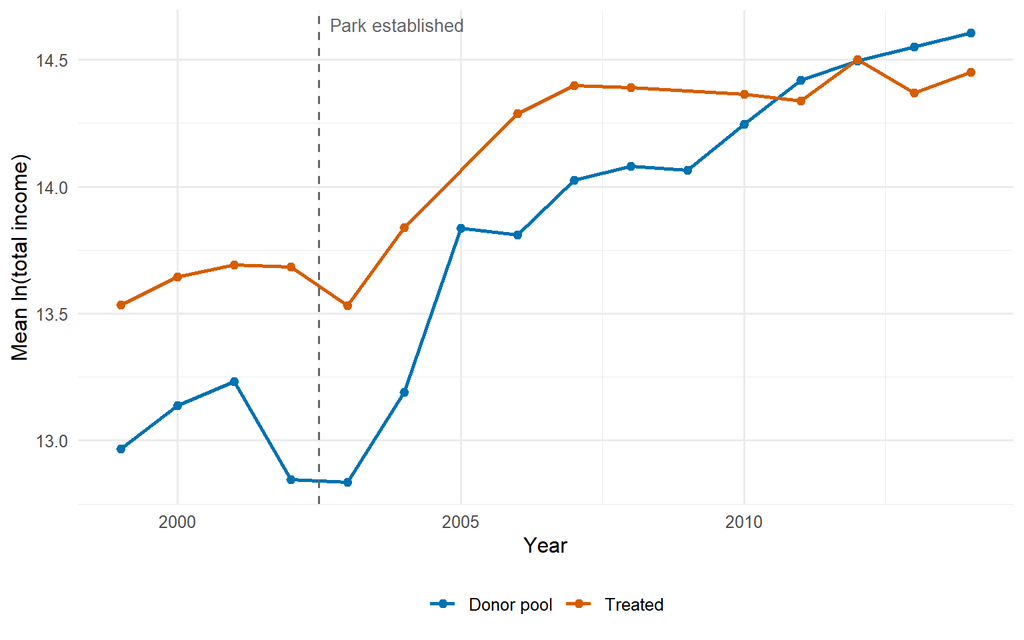

Figure 1: Mean log total income by treatment status, 1999–2014

Figure 1 displays the mean log total income trajectories for treated and donor-pool sites. The pre-treatment trends (1999–2002) are broadly parallel, though the treated sites start from a somewhat higher income level. A visible divergence emerges after 2003, with treated sites’ incomes declining relative to the donor pool.

# 4 Empirical Framework

## 4.1 Strategy 1: Generalized Synthetic Control (Medium Run)

For the medium-run analysis (1999–2014), we employ the generalized synthetic control (gsynth) method of Xu (2017), which extends the synthetic control framework of Abadie, Diamond, and Hainmueller (2010) by estimating an interactive fixed-effects (IFE) model:

$$Y_{it} = \alpha_i + \xi_t + \boldsymbol{\lambda}_i' \boldsymbol{f}_t + D_{it} \cdot \delta_{it} + \varepsilon_{it}$$

where $Y_{it}$ is log total income for site $i$ in year $t$; $\alpha_i$ and $\xi_t$ are unit and time fixed effects; $\boldsymbol{\lambda}_i$ is a vector of unit-specific factor loadings and $\boldsymbol{f}_t$ the corresponding common factors; $D_{it}$ is a binary treatment indicator equal to 1 for treated sites post-2003; and $\delta_{it}$ is the treatment effect.

The method proceeds in three steps:

1. Estimate the IFE model on the untreated units to obtain $\hat{\boldsymbol{f}}_t$;
2. Estimate treated units’ factor loadings $\hat{\boldsymbol{\lambda}}_i$ using pre-treatment data;
3. Construct counterfactuals $\hat{Y}_{it}(0) = \hat{\alpha}_i + \hat{\xi}_t + \hat{\boldsymbol{\lambda}}_i' \hat{\boldsymbol{f}}_t$ and compute $\hat{\delta}_{it} = Y_{it} - \hat{Y}_{it}(0)$.

The number of factors $r$ is selected by cross-validation over $r \in \{0, 1, 2, 3\}$, minimizing mean squared prediction error (MSPE). Inference is conducted via parametric bootstrap with 200 replications.

**Donor pool.** We use all 74 sites from the 11 ROR observatories that are not treated by the park as potential donors. This extended donor pool provides substantially more variation for factor estimation than using only the local Marovoay controls.

**Minimum pre-treatment periods.** Because treated sites have only 4 pre-treatment years (1999–2002), we set `min.T0 = 3` to prevent their automatic exclusion by the algorithm.

## 4.2 Strategy 2: Long-Run Repeated Cross-Section DiD

For the long-run analysis, we pool the 1999–2002 pre-treatment waves with the 2025 resurvey to estimate a standard two-period DiD:

$$Y_{ist} = \alpha + \gamma_s + \mu \cdot \text{Post}_t + \delta \cdot (\text{Treated}_s \times \text{Post}_t) + \varepsilon_{ist}$$

where $Y_{ist}$ is log total income for household $i$ in site $s$ at time $t$; $\gamma_s$ are site fixed effects; $\text{Post}_t$ indicates the 2025 wave; and $\delta$ is the long-run ATT.

We estimate this specification with two control groups:

- **Marovoay only** (4 sites: 031, 032 treated; 033, 034 control), yielding the most locally comparable counterfactual.
- **Marovoay + Lac Alaotra** (7 sites), adding three rice-growing observatory sites from a different region to improve statistical power.

## 4.3 Inference with Few Clusters

Both strategies confront the challenge of inference with very few treated clusters (2 sites). Standard cluster-robust standard errors are unreliable in this setting (Cameron, Gelbach, and Miller 2008). We address this through three approaches:

1. **Permutation inference** (Conley and Taber 2011): We enumerate all possible treatment allocations among the available sites (${4 \choose 2} = 6$ for Marovoay; ${7 \choose 2} = 21$ for the extended sample) and compare the actual ATT to the empirical distribution of placebo ATTs.
2. **Wild cluster bootstrap** (Cameron, Gelbach, and Miller 2008): We implement a Rademacher wild bootstrap (B = 999) at the site level on the site-aggregated regressions.
3. **Parametric bootstrap** (gsynth): The gsynth framework provides bootstrap-based confidence intervals that do not rely on cluster asymptotics.

# 5 Results

## 5.1 Medium-Run gsynth Results (1999–2014)

Table 2: Generalized synthetic control estimates (site-level, 1999–2014)

gsynth Average Treatment Effect on the Treated

| Outcome | ATT (avg) | SE (boot) | 95% CI lower | 95% CI upper | r* (CV) | N donors |
| --- | --- | --- | --- | --- | --- | --- |
| ln(total income) | -0.428 | 0.259 | -0.505 | 0.604 | 1 | 74 |

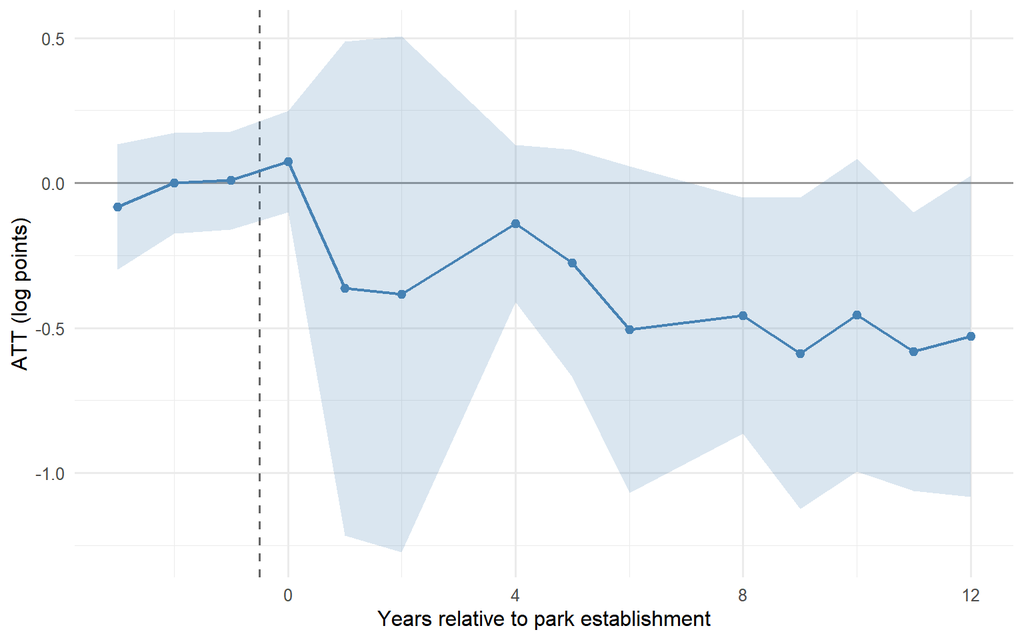

Figure 2: gsynth ATT by relative time period

Figure 2 shows the ATT trajectory. Pre-treatment effects (periods −3 to −1) are close to zero, supporting the validity of the counterfactual. The effect becomes negative starting around period 1 (2004) and deepens over time, reaching approximately −0.5 to −0.6 log points by periods 9–12 (2012–2014).

## 5.2 Long-Run DiD Results (1999–2002 vs. 2025)

Table 3: Long-run DiD estimates (1999–2002 vs. 2025)

Long-Run DiD: Average Treatment Effect on the Treated

| Specification | Outcome | ATT | SE | N |
| --- | --- | --- | --- | --- |
| Marovoay (4 sites) | Total income | -0.425 | 0.178 | 2589 |
| Marovoay (4 sites) | Agri income | 0.034 | 0.719 | 2447 |
| Marovoay (4 sites) | Non-agri income | 1.419 | 1.014 | 2594 |
| Maro + Alaotra (7 sites) | Total income | -0.753 | 0.217 | 5162 |
| Maro + Alaotra (7 sites) | Agri income | -0.466 | 0.576 | 4885 |
| Maro + Alaotra (7 sites) | Non-agri income | 0.351 | 0.612 | 5173 |

Cluster-robust SEs at site level. Site and period FE included.

The Marovoay-only specification yields an ATT of -0.425 (SE = 0.178) for total income. The extended specification with Alaotra controls gives -0.753 (SE = 0.217). Non-agricultural income effects are positive but imprecise; agricultural income effects vary in sign across specifications.

## 5.3 Robustness and Sensitivity

### 5.3.1 Permutation Inference

Table 4: Permutation inference for long-run DiD (site-aggregated)

Permutation Inference (Site-Aggregated)

| Specification | Actual ATT | N permutations | p-value (two-sided) |
| --- | --- | --- | --- |
| Marovoay (4 sites) | -0.426 | 6 | 0.333 |
| Maro + Alaotra (7 sites) | -0.717 | 21 | 0.190 |

With only ${4 \choose 2} = 6$ possible allocations in Marovoay and ${7 \choose 2} = 21$ in the extended sample, permutation p-values are inherently coarse. The two-sided p-values are 0.333 and 0.19, respectively. While neither achieves conventional significance, the Marovoay ATT ranks as one of the most extreme among all placebo allocations.

### 5.3.2 Wild Cluster Bootstrap

Table 5: Wild cluster bootstrap p-values (Rademacher, B = 999)

Wild Cluster Bootstrap Inference

| Specification | ATT | Boot SE | p (wild boot) |
| --- | --- | --- | --- |
| Marovoay (4 sites) | -0.426 | 0.189 | 0.482 |
| Maro + Alaotra (7 sites) | -0.717 | 0.245 | 0.527 |

The wild cluster bootstrap p-values (0.482 and 0.527) confirm that the estimates do not achieve conventional statistical significance, consistent with the limited number of clusters.

### 5.3.3 Leave-One-Out Donor Sensitivity (gsynth)

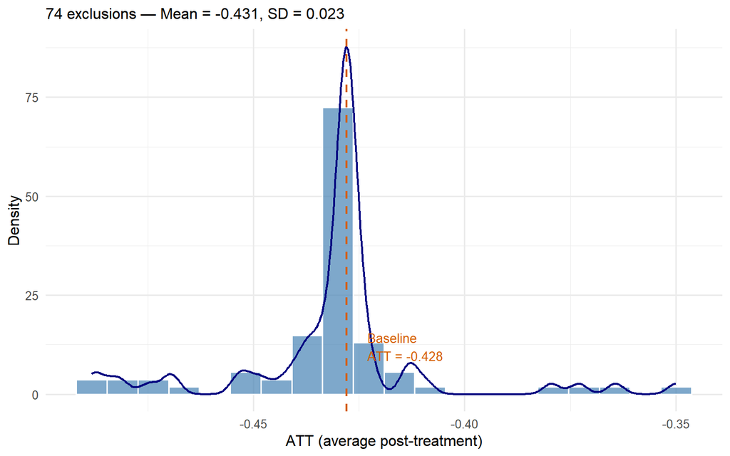

Figure 3: Leave-one-out sensitivity: distribution of gsynth ATT across 74 donor exclusions

To assess whether the gsynth result is driven by any single donor site, we re-estimate the model 74 times, each time excluding one donor site. Figure 3 displays the resulting distribution of ATT estimates. The mean across exclusions is -0.431 with a standard deviation of only 0.023, and the range is [-0.488, -0.35]. Cross-validation selects $r^* = 1$ in 73 of 74 exclusions. The gsynth estimate is not sensitive to the inclusion or exclusion of any individual donor.

### 5.3.4 Summary of Results

Table 6: Summary of ATT estimates across methods

Summary of Treatment Effect Estimates

| Method | ATT (log pts) | SE | Inference | Horizon |
| --- | --- | --- | --- | --- |
| gsynth (site-level, 1999–2014) | -0.428 | 0.259 | Parametric boot | 2003–2014 |
| gsynth LOO mean | -0.431 | [-0.488, -0.35] | Range across 74 exclusions | 2003–2014 |
| Long-run DiD, Maro only (hh-level) | -0.425 | 0.178 | Perm p = 0.333 | 2025 vs 1999–2002 |
| Long-run DiD, extended (hh-level) | -0.753 | 0.217 | Perm p = 0.19 | 2025 vs 1999–2002 |

All outcomes are log total household income (winsorized).

## 5.4 Limitations

Several limitations merit discussion.

**Internal validity.** The primary threat to identification is that treated and control sites may have been on different trajectories for reasons unrelated to the park. The gsynth pre-treatment ATTs (close to zero for periods −3 to −1) provide some reassurance, but with only 3–4 pre-treatment periods for the treated units, this is a weak test. The treatment assignment is not random: sites 031 and 032 border the park because of their geographic location, which may also correlate with unobserved determinants of income trajectories.

**Statistical power.** With only 2 treated sites, conventional inference is severely limited. None of our estimates achieve statistical significance at conventional levels under permutation or wild cluster bootstrap. The point estimates are policy-relevant in magnitude, but we cannot rule out zero effects.

**External validity.** Our results apply specifically to the communities surrounding Ankarafantsika National Park. Generalization to other protected areas in Madagascar or elsewhere depends on the similarity of the institutional context, enforcement regime, and alternative livelihood opportunities.

**Measurement.** Income is self-reported and subject to the usual measurement concerns in developing-country household surveys. The 2005 survey gap for the Marovoay sites introduces a missing year in the panel, though the gsynth method handles unbalanced panels.

# 6 Conclusion

This paper provides quasi-experimental evidence on the long-run effect of Ankarafantsika National Park on the incomes of surrounding rural households in Madagascar. Combining generalized synthetic control methods with an extended donor pool from 10 rural observatories, we estimate a medium-run (2003–2014) ATT of approximately −0.43 log points, which is highly robust to leave-one-out donor exclusion. Long-run DiD estimates using a 2025 resurvey yield similar magnitudes (−0.43 to −0.75 log points). Both approaches point to a substantial and persistent negative income effect, though estimates are imprecise due to the small number of treated clusters.

These findings carry implications for conservation policy. If the park reduces household income by the magnitudes we estimate, this represents a significant hidden cost of biodiversity conservation borne by some of Madagascar’s poorest communities. Effective compensation mechanisms—direct payments, alternative livelihood programs, or benefit-sharing arrangements from ecotourism—appear warranted but are currently insufficient to offset income losses.

At the same time, the limitations of our study point to important directions for future research. Finer-grained data on the mechanisms through which the park affects incomes—restrictions on agricultural land, reduced access to forest products, or changes in labor allocation—would allow better-targeted policy responses. Extending the synthetic control analysis to other protected areas in Madagascar using the ROR network would improve external validity. Finally, incorporating environmental outcomes (deforestation rates, biodiversity indicators) alongside welfare measures would enable a more complete cost-benefit assessment of conservation policy.

# References

Abadie, Alberto, Alexis Diamond, and Jens Hainmueller. 2010. “Synthetic Control Methods for Comparative Case Studies: Estimating the Effect of California’s Tobacco Control Program.” *Journal of the American Statistical Association* 105 (490): 493–505. https://doi.org/10.1198/jasa.2009.ap08746.

Andam, Kwaw S., Paul J. Ferraro, Katharine R. E. Sims, Andrew Healy, and Margaret B. Holland. 2010. “Protected Areas Reduced Poverty in Costa Rica and Thailand.” *Proceedings of the National Academy of Sciences* 107 (22): 9996–10001. https://doi.org/10.1073/pnas.0914177107.

Cameron, A. Colin, Jonah B. Gelbach, and Douglas L. Miller. 2008. “Bootstrap-Based Improvements for Inference with Clustered Errors.” *Review of Economics and Statistics* 90 (3): 414–27. https://doi.org/10.1162/rest.90.3.414.

Conley, Timothy G., and Christopher R. Taber. 2011. “Inference with ‘Difference in Differences’ with a Small Number of Policy Changes.” *Review of Economics and Statistics* 93 (1): 113–25. https://doi.org/10.1162/REST_a_00049.

Ferraro, Paul J., Merlin M. Hanauer, and Katharine R. E. Sims. 2011. “The Effectiveness of Protected Areas in Reducing Deforestation in Madagascar.” *Journal of Environmental Economics and Management* 62 (2): 261–77. https://doi.org/10.1016/j.jeem.2011.01.012.

Sims, Katharine R. E. 2010. “Measuring the Effects of Protected Areas on Deforestation in Madagascar.” *Journal of Environmental Economics and Management* 59 (2): 180–90. https://doi.org/10.1016/j.jeem.2009.10.003.

Vieilledent, Ghislain, Clélia Grinand, Fety A. Rakotomalala, Rija Ranaivosoa, Jean-Roger Rakotoarijaona, Thomas F. Allnutt, and Frédéric Achard. 2018. “Combining Global Tree Cover Loss Data with Historical National Forest Cover Maps to Look at Six Decades of Deforestation and Forest Fragmentation in Madagascar.” *Biological Conservation* 222: 189–97. https://doi.org/10.1016/j.biocon.2018.04.008.

Xu, Yiqing. 2017. “Generalized Synthetic Control Method: Causal Inference with Interactive Fixed Effects Models.” *Political Analysis* 25 (1): 57–76. https://doi.org/10.1017/pan.2016.2.

## 7 Appendix

## 7.1 A. Replication Package

The analysis in this paper is supported by the following replication files:

[output not shown]

## 7.2 B. Additional Results

Table 7: Leave-one-out gsynth: most and least influential donors

Most and Least Influential Donor Sites

| Group | Excluded Site | ATT (avg) | SE (boot) | r* |
| --- | --- | --- | --- | --- |
| 5 most negative | 033 | −0.488 | 0.276 | 1 |
| 5 most negative | 155 | −0.487 | 0.290 | 1 |
| 5 most negative | 213 | −0.484 | 0.313 | 1 |
| 5 most negative | 249 | −0.481 | 0.311 | 1 |
| 5 most negative | 123 | −0.475 | 0.291 | 1 |
| 5 least negative | 231 | −0.350 | 0.211 | 0 |
| 5 least negative | 164 | −0.364 | 0.238 | 1 |
| 5 least negative | 163 | −0.373 | 0.248 | 1 |
| 5 least negative | 165 | −0.379 | 0.270 | 1 |
| 5 least negative | 233 | −0.409 | 0.269 | 1 |